# Tag based TF-IDF

Shaocong Zhang

11/22/2021

Now I get the user tagging behavior data. The dataset contains user id, movie id, tag and time stamp (it represents seconds since midnight Coordinated Universal Time of January 1, 1970, but I will not use this variable in this part). Based on these information, I can construct a personalized recommendation algorithm by:

1. Count the most commonly used tags of the user.
2. For each tag, count the movies that have been labeled the most times.
3. For a user, first find his commonly used tags, and then find the most popular movies with these tags to recommend to the user.

For the above algorithm, the formula of user u’s interest in movie i is as follows:

$p(u, i)=\sum_{b} \frac{n_{u, b}}{\log \left(1+n_{b}^{(u)}\right)} \frac{n_{b, i}}{\log \left(1+n_{i}^{(u)}\right)}$

where $B(u)$ is the set of tags that user u has labeled, $B(i)$ is the set of tags that movie i is labeled, $n_{u, b}$ is the number of times that user u has labeled tag b, $n_{b, i}$ is the number of times that movie i has been labeled tag b, $n_b^{(u)}$ records how many different users have used tag b, $n_i^{(u)}$records how many different users have tagged the movie i. To get the specific value, I should build our function first.

```r
# Set up interest function
fc.interest = function(u, i) {
B.u =
  remove.tag %>%
  filter(user_id == u)

B.u.distinct =
  B.u %>%
  distinct(tag)

remove.tag.distinct =
  remove.tag %>%
  select(-movie_id, -timestamp) %>%
  distinct()

B.i =
  remove.tag %>%
  filter(movie_id == i)

B.i.distinct =
  B.i %>%
  select(-tag, -timestamp) %>%
  distinct()

n_ub = c()
n_bi = c()
n_bu = c()
lg.value = c()
n_iu = nrow(B.i.distinct)
value = c()

for (b in 1:nrow(B.u.distinct)) {
  n_ub[b] = sum(B.u$tag == as.character(B.u.distinct[b, 1]))
  n_bi[b] = sum(B.i$tag == as.character(B.u.distinct[b, 1]))
  n_bu[b] = sum(remove.tag.distinct$tag == as.character(B.u.distinct[b, 1]))
  lg.value[b] = log(1 + n_bu[b]) * log(1 + n_iu)
  value[b] = n_ub[b] * n_bi[b] / lg.value[b]
}
return(interest = round(sum(value), 2))
}
```

### Find the most popular movies and the most active users

[figure not shown]

```r
popular.movie =
  remove.tag %>%
  select(-tag, -timestamp) %>%
  distinct() %>%
  group_by(movie_id) %>%
  summarize(
    count = n()
  ) %>%
  filter(count > 3) %>%
  mutate(
    "movie id" = movie_id
  ) %>%
  select(-movie_id) %>%
  select("movie id", count) %>%
  arrange(desc(count))

active.user =
  remove.tag %>%
  select(-tag, -timestamp) %>%
  distinct() %>%
  group_by(user_id) %>%
  summarize(
    count = n()
  ) %>%
  filter(count > 20) %>%
  arrange(desc(count))

active.user.vec = as.vector(active.user$user_id)
popular.movie.vec = as.vector(popular.movie$`movie id`)

movie.name =
  movies %>%
  janitor::clean_names() %>%
  filter(movie_id %in% popular.movie.vec) %>%
  knitr::kable()

movie.name
```

| movie_id | title | genres |
| --- | --- | --- |
| 260 | Star Wars: Episode IV - A New Hope (1977) | Action\|Adventure\|Sci-Fi |
| 296 | Pulp Fiction (1994) | Comedy\|Crime\|Drama\|Thriller |
| 527 | Schindler’s List (1993) | Drama\|War |
| 541 | Blade Runner (1982) | Action\|Sci-Fi\|Thriller |
| 750 | Dr. Strangelove or: How I Learned to Stop Worrying and Love the Bomb (1964) | Comedy\|War |
| 2959 | Fight Club (1999) | Action\|Crime\|Drama\|Thriller |
| 4226 | Memento (2000) | Mystery\|Thriller |
| 4878 | Donnie Darko (2001) | Drama\|Mystery\|Sci-Fi\|Thriller |
| 7361 | Eternal Sunshine of the Spotless Mind (2004) | Drama\|Romance\|Sci-Fi |
| 8641 | Anchorman: The Legend of Ron Burgundy (2004) | Comedy |
| 79132 | Inception (2010) | Action\|Crime\|Drama\|Mystery\|Sci-Fi\|Thriller\|IMAX |

### Create heat map

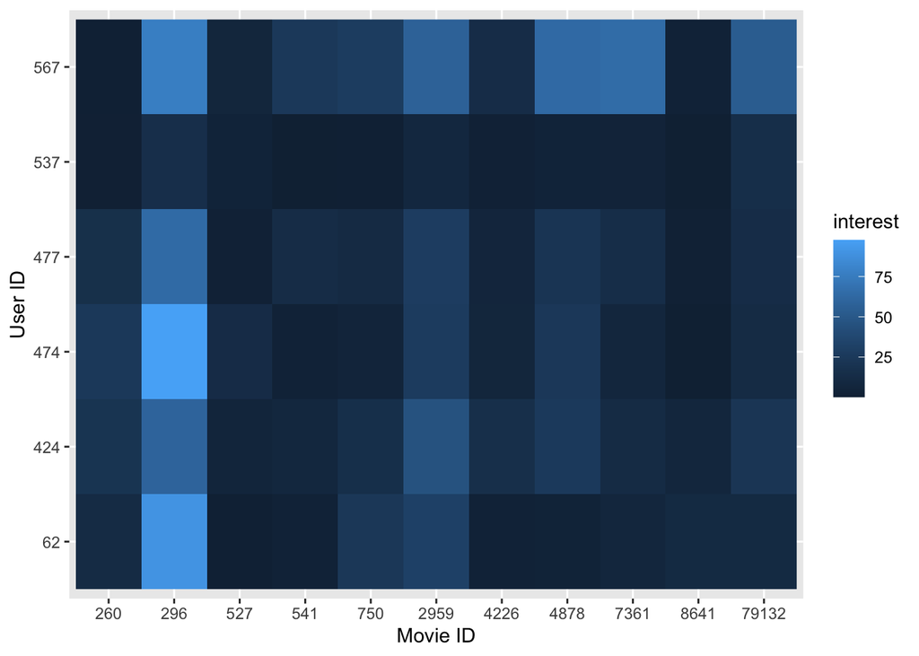

```r
# construct a new table of the selected id and movie
heat.map = tibble(user_id = rep(active.user.vec, length(popular.movie.vec)), movie_id = rep(popular.movie.vec, length(active.user.vec)))

# add insterest value to the table
interest = c()
for (i in 1:nrow(heat.map)) {
  interest[i] = fc.interest(as.numeric(heat.map[i, 1]), as.numeric(heat.map[i, 2]))
}

heat.map = add_column(heat.map, interest)

# build heat map
heat.map %>%
  ggplot(aes(y = as.factor(user_id), x = as.factor(movie_id), fill = interest)) +
  geom_tile() +
  geom_raster() +
  labs(
    x = "Movie ID",
    y = "User ID"
  )
```

### Discussion

Tag based TF-IDF can help us predict the user’s interest on a certain movie (or item). The molecule of the formula, which is $\sum_{b} n_{u, b} n_{b, i}$, firstly compute the user’s interest on a certain movie by finding the sets. $B(u)$ is the set of tags that user u has labeled, $B(i)$ is the set of tags that movie i is labeled, $n_{u, b}$ is the number of times that user u has labeled tag b and $n_{b, i}$ is the number of times that movie i has been labeled tag b

However, this formula tends to give a lot of weight to popular movies corresponding to popular tags, which will lead to recommending popular movies to users, thus reducing the novelty of the recommendation results. To solve these problem, I improve this formula by drawing on the idea of TF-IDF and construct the new formula.

$p(u, i)=\sum_{b} \frac{n_{u, b}}{\log \left(1+n_{b}^{(u)}\right)} \frac{n_{b, i}}{\log \left(1+n_{i}^{(u)}\right)}$,

where $n_b^{(u)}$ records how many different users have used tag b, $n_i^{(u)}$records how many different users have tagged the movie i. The denominator of the formula is used to appropriately punish popular labels and popular items, but the results will not reduce the offline accuracy of the recommendation results while enhancing the personalization of the recommendation results.

Although I got the interest function of user u on movie i, it was still hard to create the heat map. The main problem was the small dataset. The dataset only contains 58 users and most of them only labeled 1 movie. In this way, if the sample size is not large enough, $n_{b, i}$, which is the number of times that movie i has been labeled tag b, will always be 0. Then I cannot predict the user’s interest anymore and the heat map then will be bad and doesn’t contain useful information.

Luckily, there are several movies are popular and some users are active. That is, the movies were labeled by several users and some users labeled numbers of movies. I selected the popular movies and active users and then created a heat map.

It is conceivable that if the sample data set is large enough, then I will be able to get the interest of any user for any movie and form a movie recommendation system based on it. For example, the size of the interest is delineated, and the movie is recommended to the user if it is larger than a certain value; the users with similar movie watching interests can be grouped together, and the movie with the highest interest value in this group of users’ will be recommended. In this project, because of the limited sample dataset, time and experience, I could not go deeper. But I am confident that this is a successful attempt.